# Report on Shopping Data-set

2023-03-17

## Introduction

The data-set consists of information on 11630 user sessions of an e-commerce website wherein we have 17 covariates and the response variable, an indicator to show if a purchase was made. We look for an explanatory model with specific attention to the data-related features in the data. Lastly, we report the AUC for the final model. We observe that the data set is heavily imbalanced with only 1905 instances where a purchase is made.

We look at the structure of the data -

```
## 'data.frame':    11630 obs. of  19 variables:
##  $ n_admin                 : int  0 0 0 0 0 0 0 0 0 0 ...
##  $ time_admin              : num  0 0 0 0 0 0 0 0 0 0 ...
##  $ n_info                  : int  0 0 0 0 0 0 0 0 0 0 ...
##  $ time_info               : num  0 0 0 0 0 0 0 0 0 0 ...
##  $ product_related         : int  2 2 10 19 2 3 3 16 7 6 ...
##  $ product_related_duration: num  64 2.67 627.5 154.22 37 ...
##  $ bounce_rates            : num  0 0.05 0.02 0.0158 0 ...
##  $ exit_rates              : num  0.1 0.14 0.05 0.0246 0.1 ...
##  $ page_values             : num  0 0 0 0 0 0 0 0 0 0 ...
##  $ special_day             : num  0 0 0 0 0.8 0.4 0 0.4 0 0 ...
##  $ month                   : chr  "Feb" "Feb" "Feb" "Feb" ...
##  $ operating_systems       : Factor w/ 5 levels "1","2","3","4",..: 2 3 3 2 2 2 1 1 1 2 ...
##  $ browser                 : Factor w/ 3 levels "1","2","Other": 2 2 3 2 2 3 1 1 1 3 ...
##  $ region                  : Factor w/ 9 levels "1","2","3","4",..: 1 2 1 1 2 1 3 4 1 1 ...
##  $ traffic_type            : Factor w/ 12 levels "1","2","3","4",..: 2 4 4 3 3 2 3 3 3 3 ...
##  $ visitor_type            : chr  "Returning_Visitor" "Returning_Visitor" "Returning_Visitor" "Returning_Visitor" ...
##  $ weekend                 : logi  FALSE FALSE TRUE FALSE FALSE FALSE ...
##  $ purchase                : logi  FALSE FALSE FALSE FALSE FALSE FALSE ...
##  $ nocookies               : logi  TRUE TRUE TRUE TRUE TRUE TRUE ...
```

## Exploration of the Data

First, we discuss the date-related features. These are the Month, Weekend and Special Day.

Special Day indicates the closeness of the session to an occasion like Christmas, taking into account Delivery and Other factors. We explore the construction of this feature via Figure 1.

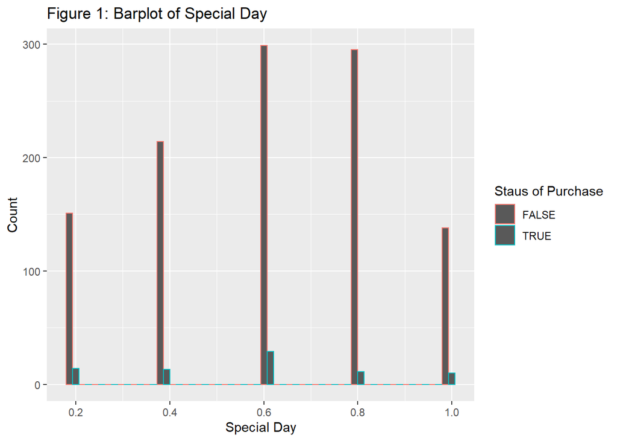

We observe the lack of a linear relationship between the number of sales and the Special-Day covariate in Figure 1. This suggests that the feature Special Day may not be very informative about the number of purchases in the session or that the relationship may not be linear. It is possible that it is informative about the price of the items/services but we do not have data regarding this to make a definitive comment.

For the month, we see in Table 1 that while we see the largest percentage of session with sales as a percentage of total sessions, we also see that the percentage of sessions that are converted to sales is abnormally low in February compared to other months. Furthermore, we observe that the data does not have sessions for January and April. Thus, we were not able to club the months according to Pairs/Quarters and had to leave them as is.

Table 1: Effect of Month on Sale for each session

|  | Feature | Aug | Dec | Feb | Jul | June | Mar | May | Nov | Oct | Sep |
| --- | --- | --- | --- | --- | --- | --- | --- | --- | --- | --- | --- |
| 1 | Sessions without a Sale | 345.00 | 1411.00 | 147.00 | 345.00 | 233.00 | 1583.00 | 2786.00 | 2091.00 | 428.00 | 356.00 |
| 2 | Sessions with a Sale | 76.00 | 216.00 | 3.00 | 66.00 | 29.00 | 192.00 | 365.00 | 758.00 | 114.00 | 86.00 |
| 3 | Total Sessions | 421.00 | 1627.00 | 150.00 | 411.00 | 262.00 | 1775.00 | 3151.00 | 2849.00 | 542.00 | 442.00 |
| 4 | Percentage of Sessions ending with a Sale | 18.05 | 13.28 | 2.00 | 16.06 | 11.07 | 10.82 | 11.58 | 26.61 | 21.03 | 19.46 |

Similarly, we see in Table 2 that the weekend feature is not particularly informative as the proportion of sales do not vary significantly in either case for the Weekend covariate.

Table 2: Effect of Weekend on Sale for each session

|  |  | FALSE | TRUE |
| --- | --- | --- | --- |
| 1 | No Purchase | 7481.00 | 1406.00 |
| 2 | Purchase | 2244.00 | 499.00 |
| 3 | Total Sessions | 9725.00 | 1905.00 |
| 4 | Percentage of Sessions ending wih a Sale | 23.07 | 26.19 |

Now, we look at the Google Analytics features. They are the Bonce Rate, Page Value and Exit Rate.

The Page Value is a representation of the relative importance of the monetary value of a page for the advertiser/customer. While it is not readily interpretable, it is supposed to inform the advertiser about the average monetary value generated by the page in each session. More information is available at [Google help](https://support.google.com/analytics/answer/2695658?hl=en).

One would also imagine that the customer would terminate the session after making the purchase. In such a case, the exit-rate covariate, which is the average exit rate of the visited pages in a session, will also be useful. Analytics also reports the average Bounce Rate, where Bounce rate is the proportion of users who exit the webpage without triggering any new requests during their session. We do not believe this feature is useful, as in our experience, after making a purchase, the user usually checks the Delivery data or some other useful information on the webpage.

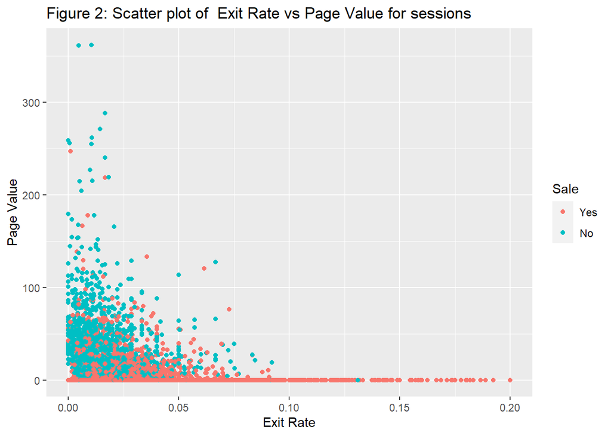

We observe that our intuition regarding Exit Rate, in that a large average Exit rate corresponds to a sale in the session, was correct. It is not clear that the Page Value is useful, as the sessions with a high page value don’t necessarily correspond to a session where a purchase was made. We cannot discard this covariate at this stage as it is supposed to encode the importance of a webpage by construction. In the later analysis, we can choose to discard it if it is not useful.

We also observe that the two features appear to be inversely correlated, thus being against the intuition that highly valuable/target pages for a sale are the pages with a high Page Value. On calculating the correlation, we observe that it is -0.186. Thus, even though the correlation is negative, it is not highly negative, and we might be able to extract some useful information from these two covariates.

The Data also has information related to the number of Informational, Administrative and Product related pages visited during each session and the time spent on each category. Since these covariates span a large range and are extremely skewed to the left, we were not able to find a good way to visualise them.

Lastly, we observe that we have data regarding miscellaneous features like Operating Systems, Browser, Region, Traffic Type and Visitor type. We choose to not explore the Browser, Operating System and Region because we do not expect them to be informative.

## Statistical Analysis

We start with a first model containing all the covariates and use the BIC for preliminary feature selection. We use the stepAIC function in the MASS package to arrive at the second model

$$log(\frac{p}{1-p}) = 7.98 \times
10^{-5}\cdot \text{Prod}_{\text{Duration}} - 18.0 \cdot \text{Exit Rate}
+ 8.09 \times 10^{-2}\cdot \text{Page Values} + C_{\text{Month}}
\text{Month}$$

Now, we expect that a few sessions would have disabled cookies. We decide to mark a session to have disabled cookies if both the number and of and the time spent on Administrative and Informational Pages is zero. We incorporate this in the third model and the result is as follows -

$$log(\frac{p}{1-p}) = 7.22 \times
10^{-5}\cdot \text{Prod}_{\text{Duration}} - 11.3 \cdot \text{Exit Rate}
+ 6.76 \times 10^{-2}\cdot \text{Page Values} + C_{\text{Month}}
\text{Month} \\ + 6.78 \times 10^{-1} \cdot \mathbb{1}_{\text{No
cookies}} + 6.78 \times 10^{-1} \cdot \mathbb{1}_{\text{No cookies}}
\cdot \text{Exit Rate} \\ + 9.06 \times 10^{-2} \cdot
\mathbb{1}_{\text{No cookies}} \cdot \text{Page Value} + 1.16 \times
10^{-4} \cdot\mathbb{1}_{\text{No cookies}} \cdot
\text{Prod}_{\text{Duration}}$$

Now, we consider the possible interaction terms which can be helpful for explaining the variability in the model. Among the selected covariates, we expect to have some interaction between Page Value and Exit rates. We allow for all possible interactions in the model between the non-categoical predictors to reach the fourth model. Thus, we get that the fourth model is -

$$log(\frac{p}{1-p}) = 2.07 \times 10^{-4}\cdot
\text{Prod}_{\text{Duration}} - 4.8 \cdot \text{Exit Rate} + 8.59 \times
10^{-2}\cdot \text{Page Values} + C_{\text{Month}} \text{Month} \\ +
6.06 \times 10^{-1} \mathbb{1}_{\text{No cookies}} + 17.37 \times
10^{-1} \cdot \mathbb{1}_{\text{No cookies}} \cdot \text{Exit
Rate} \\ + 9.29 \times 10^{-2} \mathbb{1}_{\text{No cookies}}
\cdot \text{Page Value} + 1.12 \times 10^{-4}
\cdot \mathbb{1}_{\text{No cookies}} \cdot
\text{Prod}_{\text{Duration}} \\ - 2.83 \cdot \text{Exit Rate} \cdot
\text{Page Values} -4.87 \times 10^{-3}\cdot
\text{Prod}_{\text{Duration}} \cdot \text{Exit Rate} \\- 8.56 \times
10^{-3}\cdot \text{Prod}_{\text{Duration}} \cdot \text{Page Value}$$

We also decide to add the corresponding interaction terms for the no-coookies case.We will simplify the model and remove the extra interactions later. So far, the model we have that the fifth model is as follows -

$$log(\frac{p}{1-p}) = 2.06 \times
10^{-4}\cdot \text{Prod}_{\text{Duration}} - 4.47 \cdot \text{Exit Rate}
+ 8.58 \times 10^{-2}\cdot \text{Page Values} + C_{\text{Month}}
\text{Month} \\ + 6.56 \times 10^{-1} \mathbb{1}_{\text{No cookies}}
-18.5 \mathbb{1}_{\text{No cookies}} \text{Exit Rate} \\ + 1.21
\times 10^{-1} \mathbb{1}_{\text{No cookies}} \text{Page Value} + 1.38
\times 10^{-4} \mathbb{1}_{\text{No cookies}}
\text{Prod}_{\text{Duration}} \\ - 3.32 \times 10^{-1}\cdot \text{Exit
Rate} \cdot \text{Page Values} -4.89 \times 10^{-3}\cdot
\text{Prod}_{\text{Duration}} \cdot \text{Exit Rate} \\- 7.95 \times
10^{-3}\cdot \text{Prod}_{\text{Duration}} \cdot \text{Page Value} \\ -
2.66 \times 10^{-5} \mathbb{1}_{\text{No cookies}}
\text{Prod}_{\text{Duration}} \text{Page Value} \\+ 1.82 \times 10^{-3}
\mathbb{1}_{\text{No cookies}} \text{Prod}_{\text{Duration}} \text{Exit
Rate}$$
To simplify the model, we use the Anova function from the ‘car’ package to do a Likelihood Ratio Test to asses the importance of each covariate. We see in Table 3 that the interaction between the exit rate and page value is not significant and we decide to drop it.

Table 3: Anova Table for Model 5

|  | LR Chisq | Df | Pr(>Chisq) |
| --- | --- | --- | --- |
| product_related_duration | 38.23 | 1 | 0.0000 |
| exit_rates | 77.55 | 1 | 0.0000 |
| page_values | 2106.19 | 1 | 0.0000 |
| month | 971.66 | 10 | 0.0000 |
| I(nocookies) | 29.20 | 1 | 0.0000 |
| exit_rates:I(nocookies) | 16.60 | 1 | 0.0000 |
| page_values:I(nocookies) | 134.45 | 1 | 0.0000 |
| product_related_duration:I(nocookies) | 3.50 | 1 | 0.0612 |
| exit_rates:page_values | 3.31 | 1 | 0.0687 |
| product_related_duration:exit_rates | 14.15 | 1 | 0.0002 |
| product_related_duration:page_values | 38.50 | 1 | 0.0000 |
| product_related_duration:page_values:I(nocookies) | 12.41 | 1 | 0.0004 |
| product_related_duration:exit_rates:I(nocookies) | 0.18 | 1 | 0.6721 |

Thus, we have the sixth model -

$$log(\frac{p}{1-p}) = 2.10 \times
10^{-4}\cdot \text{Prod}_{\text{Duration}} - 6.14 \cdot \text{Exit Rate}
+ 8.01 \times 10^{-2}\cdot \text{Page Values} + C_{\text{Month}}
\text{Month} \\+ 4.23 \times 10^{-1} \cdot \mathbb{1}_{\text{No
cookies}} + 18.9 \cdot \mathbb{1}_{\text{No cookies}} \cdot \text{Exit
Rate} + 1.09 \times 10^{-1} \cdot \mathbb{1}_{\text{No cookies}} \cdot
\text{Page Value} \\ -4.82 \times 10^{-3}\cdot
\text{Prod}_{\text{Duration}} \cdot \text{Exit Rate} - 7.96 \times
10^{-3}\cdot \text{Prod}_{\text{Duration}} \cdot \text{Page Value} \\-
2.00 \times 10^{-5} \mathbb{1}_{\text{No cookies}} \cdot
\text{Prod}_{\text{Duration}} \cdot \text{Page Value}$$

We compare this model to the second model using the likelihood ratio test to get the analysis of deviance table.

Table 4: Anova Test for model 6 with respect to model 2

|  | Resid. Df | Resid. Dev | Df | Deviance | Pr(>Chi) |
| --- | --- | --- | --- | --- | --- |
| 1 | 11616 | 7123.82 |  |  |  |
| 2 | 11611 | 6885.05 | 5 | 238.77 | 0.0000 |

Thus, from Table 4, we see that model 6 explains significantly more variability in the Data compared to the Bare-bones model using the BIC feature selection in model 2. Now, we will use the Anova function in car to asses the importance of each covariate and remove the less important ones. We see that all terms are important and we can report an AUC of 0.8946. Since this is below the benchmark, we fall back on model 5 and use it as the final model. It has the AUC of 0.895 and provisionally, we declare it as our final model.

## Discussion of Date Related Features

We observe that the Weekend and Special Day covariates in the model were removed in the initial stage itself by the BIC feature selection. Thus, we used the GLRT to asses importance of these features and how the odds of a purchase are affected by it.

## Diagnostics

We make a diagnostic plot for each co-ordinate over here. As discussed in class, we look at the trend lines and not at the individual residuals. We see that the trend lines for each covariate look uninformative. This suggests that model 7 has an adequate fit to the data as the bulk of the data is within a $\pm2$ band. We point out that the trends for product related duration and number of product related pages appear to be quadratic but on further inspection, we see that this is only because of a few residual values and there is not enough data in those regions of the corresponding residual plots to warrant a quadratic term for these covariates.

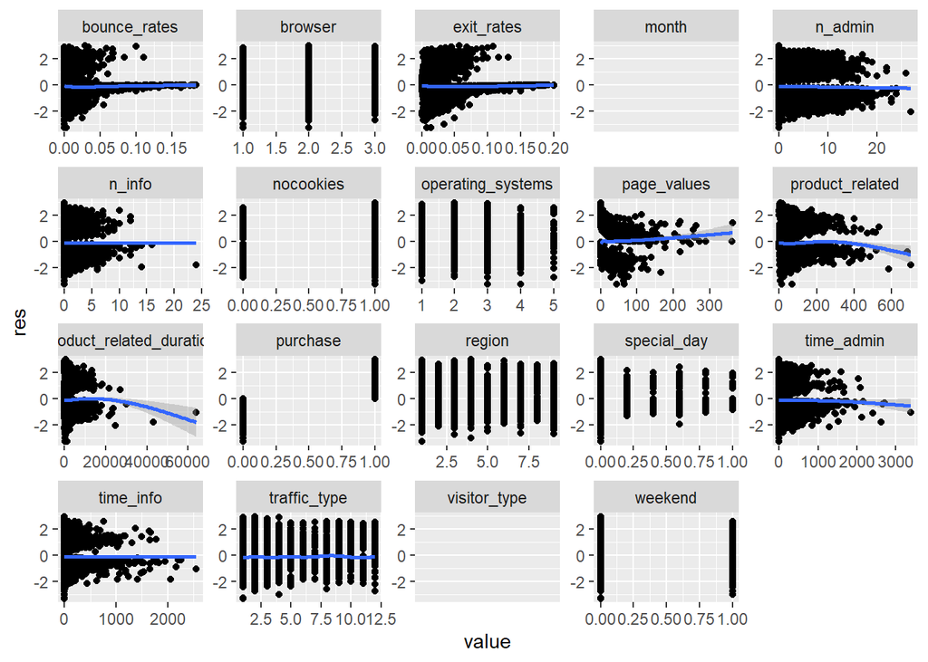

Lastly, we look at the diagnostic plot of Leverage vs Cook’s distance for model 7 and observe hat the model has a satisfactory fit to the data. While there is one high leverage point, it has a low cooks Distance and overall, the residuals are tightly within the thumb rule of the Cook’s distance 0.5 or 1. We remark that when we looked at the Cook’s distance with the threshold $\frac{8}{n - 2p}$, we remark that quite a few values were above the threshold. Thus, we cannot say that the model is adequately fitted to the data. Since the aim of this project is prediction, we choose to not explore this further.

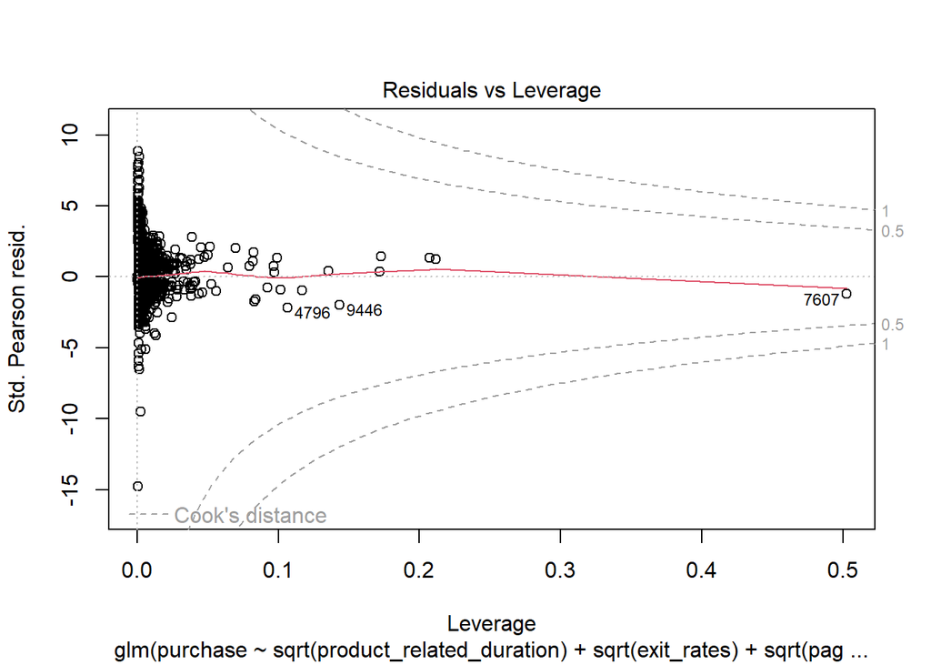

## Final Model

Even though model 7 is not readily interpretable, we declare model 7 as the final model because it is the best according to the AIC, AUC and the Residual Deviance. Thus, we have that

Table 5: Model evaluation for the best Models

| Model type | AIC | AUC | Residual Deviance |
| --- | --- | --- | --- |
| Model 5, Readily Interpretable | 6923 | 0.8952 | 6885 |
| Model 7, Less Interpretable | 6008 | 0.9194 | 5960 |

We see that model 7 is significantly better than model 5 by each metric, and we see a very significant impact on the AIC, even though we have added three new covariates by taking square roots. Similarly, we see a significant drop in the Residual Deviance and a sharp rise in the AUC. Thus, our choice in keeping model 7 as the final model is justified.

## Coefficients of the Final model

Table 6: Coefficients for the Final Model

|  | Estimate | Std. Error | z value | Pr(>\|z\|) |
| --- | --- | --- | --- | --- |
| sqrt(product_related_duration) | -0.0032 | 0.0043 | -0.74 | 0.4599 |
| sqrt(exit_rates) | 4.6672 | 2.8707 | 1.63 | 0.1040 |
| sqrt(page_values) | 1.0295 | 0.0323 | 31.88 | 0.0000 |
| monthAug | -3.2158 | 0.3097 | -10.38 | 0.0000 |
| monthDec | -3.6518 | 0.2832 | -12.89 | 0.0000 |
| monthFeb | -4.5557 | 0.6957 | -6.55 | 0.0000 |
| monthJul | -3.1373 | 0.3137 | -10.00 | 0.0000 |
| monthJune | -3.5634 | 0.3689 | -9.66 | 0.0000 |
| monthMar | -3.6215 | 0.2788 | -12.99 | 0.0000 |
| monthMay | -3.9386 | 0.2773 | -14.20 | 0.0000 |
| monthNov | -2.4299 | 0.2743 | -8.86 | 0.0000 |
| monthOct | -3.2911 | 0.2936 | -11.21 | 0.0000 |
| monthSep | -3.2431 | 0.3052 | -10.63 | 0.0000 |
| I(nocookies)TRUE | -0.1883 | 0.1968 | -0.96 | 0.3387 |
| exit_rates | -9.5327 | 8.5854 | -1.11 | 0.2669 |
| page_values | -0.0328 | 0.0041 | -7.96 | 0.0000 |
| product_related_duration | 0.0002 | 0.0000 | 4.35 | 0.0000 |
| I(nocookies)TRUE:exit_rates | -18.8803 | 4.6646 | -4.05 | 0.0001 |
| I(nocookies)TRUE:page_values | 0.0724 | 0.0097 | 7.49 | 0.0000 |
| I(nocookies)TRUE:product_related_duration | 0.0002 | 0.0001 | 2.98 | 0.0029 |
| exit_rates:page_values | -1.1383 | 0.1490 | -7.64 | 0.0000 |
| exit_rates:product_related_duration | -0.0048 | 0.0014 | -3.38 | 0.0007 |
| page_values:product_related_duration | -0.0000 | 0.0000 | -7.45 | 0.0000 |
| I(nocookies)TRUE:page_values:product_related_duration | -0.0000 | 0.0000 | -4.02 | 0.0001 |